# Assignment 3 - Mushroom Classification Study, DM855

Jonatan Møller Gøttcke

2018 M05 3

setwd(dirname(rstudioapi::getActiveDocumentContext()$path)) # This is for general case setting working directory.

## Setup of working

```r
library(rstudioapi)
library(e1071)
library(caret)
library(randomForest)
```

```r
library(ggplot2)
library(knitr)
library(ROCR)
library(DiagrammeR)
library(caret)
library(mlbench)
library(pROC)
library(dplyr)
library(igraph)
library(ggraph)
library(class) # Order is important (masks knn function from igraph)
library(nnet)
```

# Reasoning for choosing the dataset

The mushroom dataset, is an older dataset from 1987 and is quite well studied. It is classified as a classification dataset on the UCI website, because it contains labeled data, and has been used in many classification studies. It is interesting because it only contains nominal/categorical data, and my experience with nominal data is limited. In addition to being kind of a mycologist myself, and having a personal interest in solving this classifiation problem (to avoid being poisoned), I also expect decision trees to perform well in this domain, unlike some of the other models we have seen in the course such as Naïve Bayes. The dataset was also chosen because of the relatively high dimensionality and relatively high number of samples.

## Loading data

```r
mushroom_data <- read.csv("../data/agaricus-lepiota.data", header = F,stringsAsFactors = TRUE)
names <- c("Class", "capshape","capsurface","capcolor","bruises","odor","gillattachment","gillspacing","gillsize","gillcolor","stalkshape","stalkroot","stalksurfaceabovering","stalksurfacebelowring","stalkcolorabovering","stalkcolorbelowring","veiltype","veilcolor",
"ringnumber","ringtype","sporeprintcolor","population","habitat")
length(names)
```

```
## [1] 23
```

```r
ncol(mushroom_data)
```

```
## [1] 23
```

```r
colnames(mushroom_data) = names #Renaming so we know what is class label, and which are attributes. Could also just have changed in the file, but in this way the reader can tag along.
colnames(mushroom_data)
```

```
##  [1] "Class"                 "capshape"
##  [3] "capsurface"            "capcolor"
##  [5] "bruises"               "odor"
##  [7] "gillattachment"        "gillspacing"
##  [9] "gillsize"              "gillcolor"
## [11] "stalkshape"            "stalkroot"
## [13] "stalksurfaceabovering" "stalksurfacebelowring"
## [15] "stalkcolorabovering"   "stalkcolorbelowring"
## [17] "veiltype"              "veilcolor"
## [19] "ringnumber"            "ringtype"
## [21] "sporeprintcolor"       "population"
## [23] "habitat"
```

## Summary

```r
summary(mushroom_data)
```

```
##  Class    capshape capsurface    capcolor    bruises       odor
##  e:4208   b: 452   f:2320     n      :2284   f:4748   n      :3528
##  p:3916   c:   4   g:   4     g      :1840   t:3376   f      :2160
##           f:3152   s:2556     e      :1500            s      : 576
##           k: 828   y:3244     y      :1072            y      : 576
##           s:  32              w      :1040            a      : 400
##           x:3656              b      : 168            l      : 400
##                               (Other): 220            (Other): 484
##  gillattachment gillspacing gillsize   gillcolor    stalkshape stalkroot
##  a: 210         c:6812      b:5612   b      :1728   e:3516     ?:2480
##  f:7914         w:1312      n:2512   p      :1492   t:4608     b:3776
##                                      w      :1202              c: 556
##                                      n      :1048              e:1120
##                                      g      : 752              r: 192
##                                      h      : 732
##                                      (Other):1170
##  stalksurfaceabovering stalksurfacebelowring stalkcolorabovering
##  f: 552                f: 600                w      :4464
##  k:2372                k:2304                p      :1872
##  s:5176                s:4936                g      : 576
##  y:  24                y: 284                n      : 448
##                                              b      : 432
##                                              o      : 192
##                                              (Other): 140
##  stalkcolorbelowring veiltype veilcolor ringnumber ringtype
##  w      :4384        p:8124   n:  96    n:  36     e:2776
##  p      :1872                 o:  96    o:7488     f:  48
##  g      : 576                 w:7924    t: 600     l:1296
##  n      : 512                 y:   8               n:  36
##  b      : 432                                      p:3968
##  o      : 192
##  (Other): 156
##  sporeprintcolor population habitat
##  w      :2388    a: 384     d:3148
##  n      :1968    c: 340     g:2148
##  k      :1872    n: 400     l: 832
##  h      :1632    s:1248     m: 292
##  r      :  72    v:4040     p:1144
##  b      :  48    y:1712     u: 368
##  (Other): 144               w: 192
```

```r
set.seed(123) #Setting the random seed, for reproducibility
```

```r
indices_without_17 <- c(1:16,18:ncol(mushroom_data))
 # The 17'th column only contains 1 attribute value, so it is omitted.
mushroom_data <- mushroom_data[,indices_without_17]
mushroom_data_nolabel <- mushroom_data[,2:ncol(mushroom_data)]
summary(mushroom_data)
```

```
##  Class    capshape capsurface    capcolor    bruises       odor
##  e:4208   b: 452   f:2320     n      :2284   f:4748   n      :3528
##  p:3916   c:   4   g:   4     g      :1840   t:3376   f      :2160
##           f:3152   s:2556     e      :1500            s      : 576
##           k: 828   y:3244     y      :1072            y      : 576
##           s:  32              w      :1040            a      : 400
##           x:3656              b      : 168            l      : 400
##                               (Other): 220            (Other): 484
##  gillattachment gillspacing gillsize   gillcolor    stalkshape stalkroot
##  a: 210         c:6812      b:5612   b      :1728   e:3516     ?:2480
##  f:7914         w:1312      n:2512   p      :1492   t:4608     b:3776
##                                      w      :1202              c: 556
##                                      n      :1048              e:1120
##                                      g      : 752              r: 192
##                                      h      : 732
##                                      (Other):1170
##  stalksurfaceabovering stalksurfacebelowring stalkcolorabovering
##  f: 552                f: 600                w      :4464
##  k:2372                k:2304                p      :1872
##  s:5176                s:4936                g      : 576
##  y:  24                y: 284                n      : 448
##                                              b      : 432
##                                              o      : 192
##                                              (Other): 140
##  stalkcolorbelowring veilcolor ringnumber ringtype sporeprintcolor
##  w      :4384        n:  96    n:  36     e:2776   w      :2388
##  p      :1872        o:  96    o:7488     f:  48   n      :1968
##  g      : 576        w:7924    t: 600     l:1296   k      :1872
##  n      : 512        y:   8               n:  36   h      :1632
##  b      : 432                             p:3968   r      :  72
##  o      : 192                                      b      :  48
##  (Other): 156                                      (Other): 144
##  population habitat
##  a: 384     d:3148
##  c: 340     g:2148
##  n: 400     l: 832
##  s:1248     m: 292
##  v:4040     p:1144
##  y:1712     u: 368
##             w: 192
```

To have some test data and some training data, I do a simple split, so that we can build a model on a part of the data and validate on the other part of the data.

## Gaining insight into the data

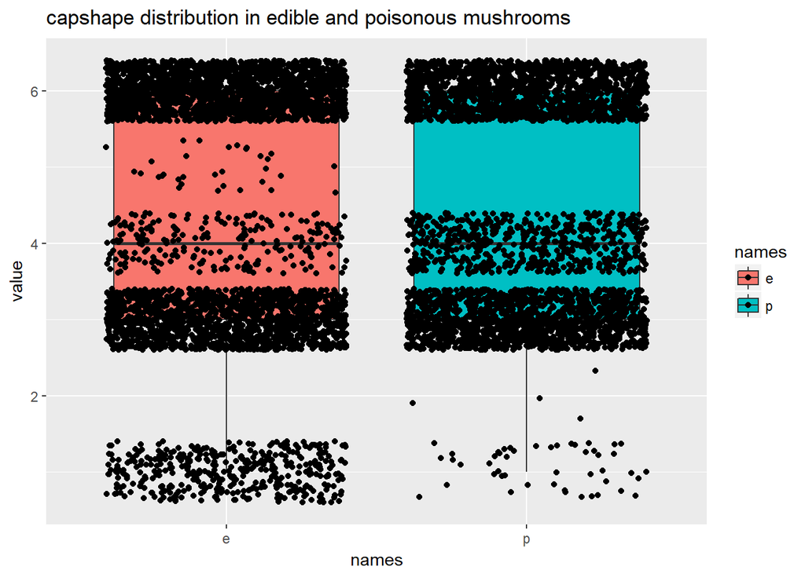

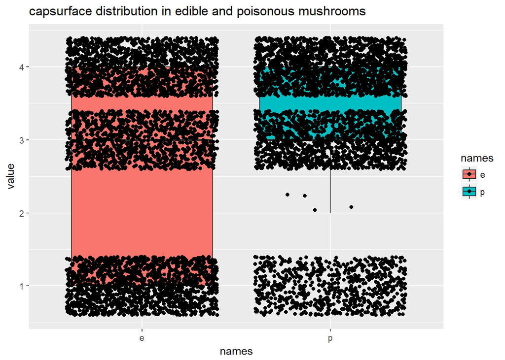

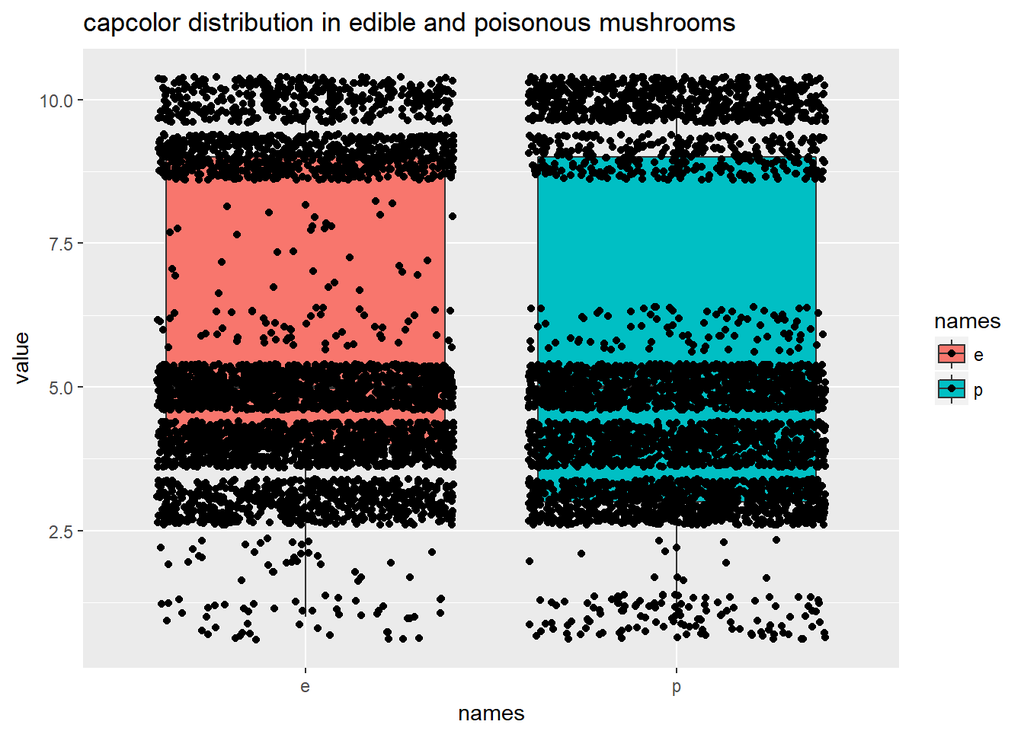

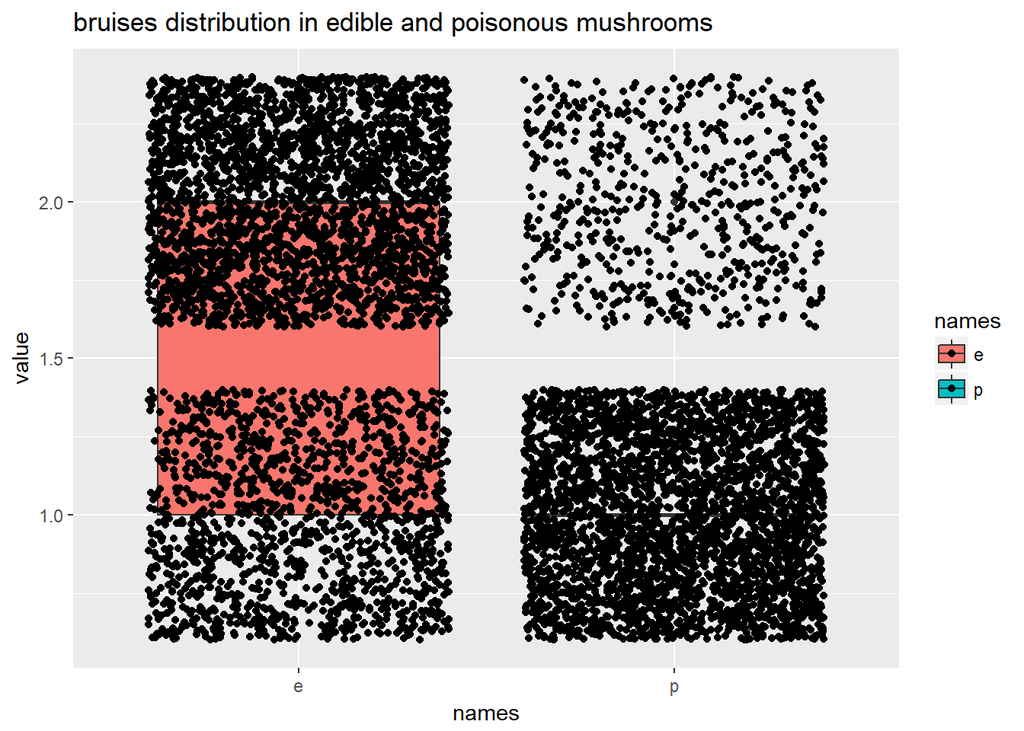

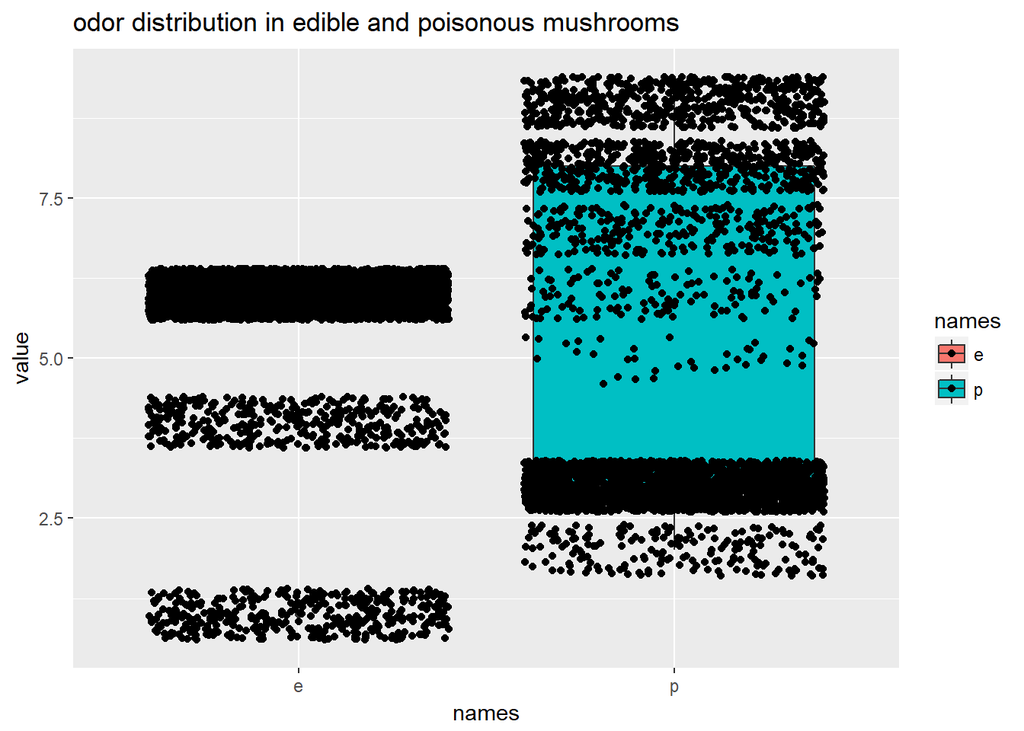

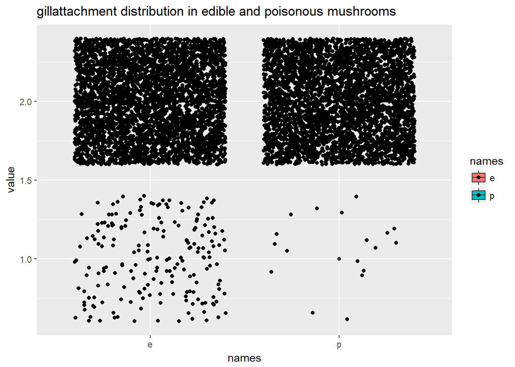

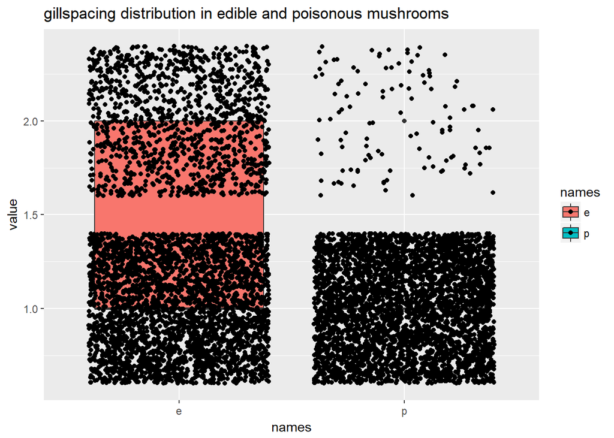

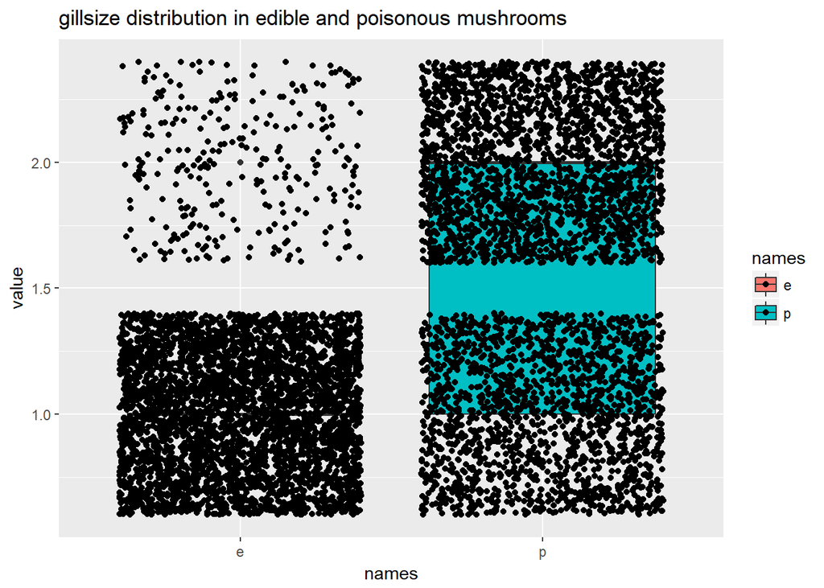

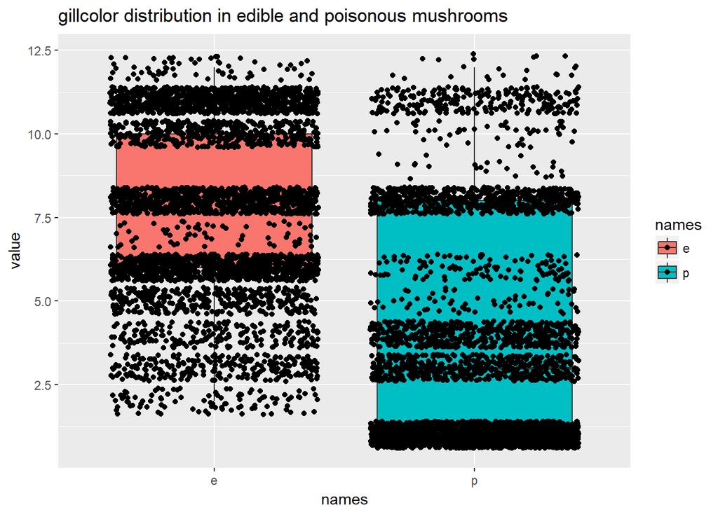

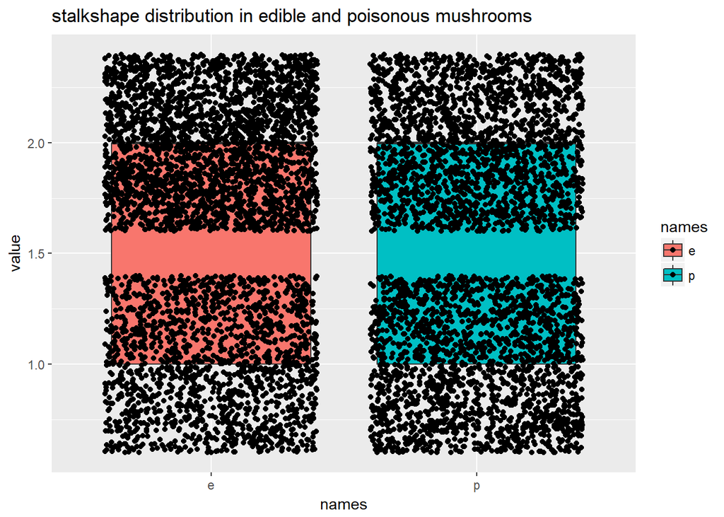

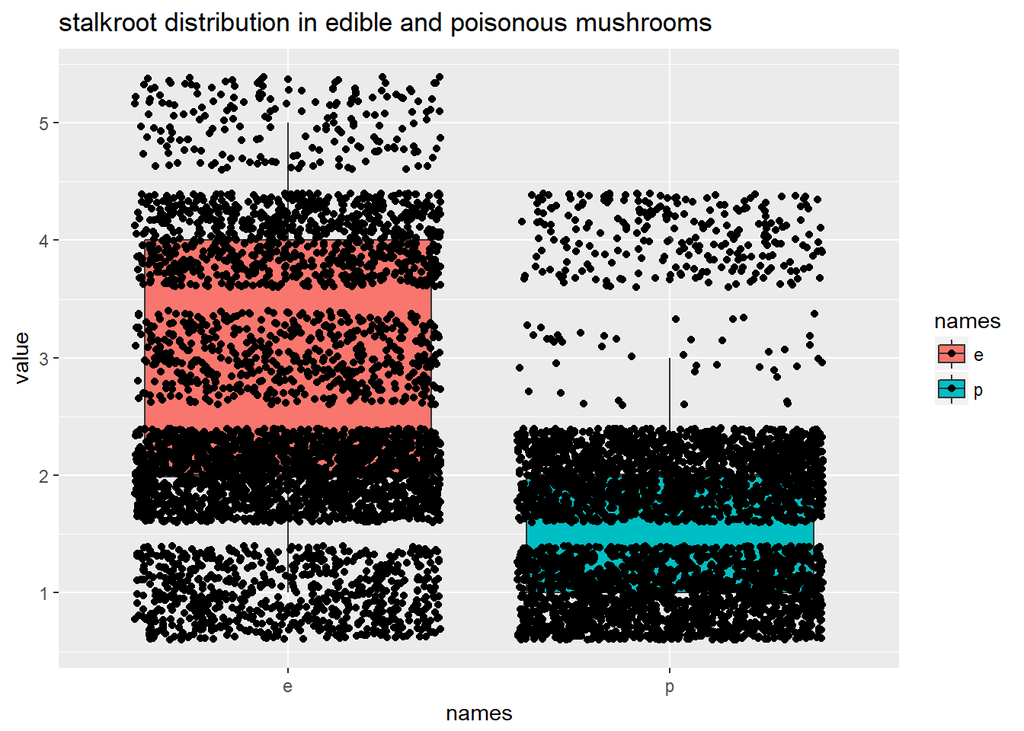

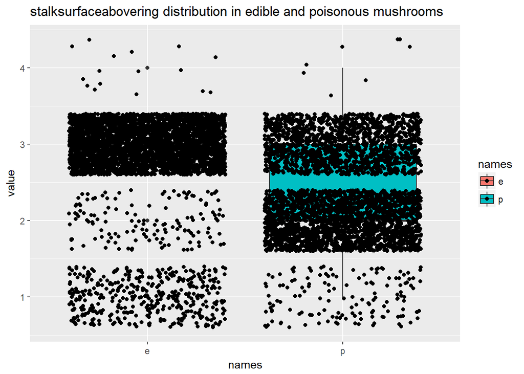

[9 more figures not shown]

```r
for (i in 2:22) {
index <- i
names = c(rep("e",length(which(mushroom_data[,1] == "e"))),rep("p",length(which(mushroom_data[,1] == "p"))))
value = c(mushroom_data[which(mushroom_data[,1] =="e"),index],mushroom_data[which(mushroom_data[,1] =="p"),index])
data = data.frame(names,value)
attribute_boxplot <- qplot( x=names , y=value , data=data , geom=c("boxplot","jitter") , fill=names)
?qplot
print(attribute_boxplot + ggtitle(paste(names(mushroom_data[index]), "distribution in edible and poisonous mushrooms")))

}
```

### Attributes

Here the attributes are shown as boxplots, to see how the values for each attribute are distributed dependant on the class label. This way of plotting the data gives us a clear insight into how we can distinguish poisonous mushrooms from edible mushrooms, attribute by attribute and give an indication of what the classifiers will probably learn. The data is plotted in this way because it is nominal/categorical, and it doesn’t make much sense to plot it in a cartesian coordinate system. Another reason for plotting the data in this manner, is because of the high dimensionality, so if we did 2-dimensional plots, there would be 22 choose 2 (231) combinations of plots to show. Some very similar attributes are *capcolor* and *capsurface* and very dissimilar attributes are for instance *odor* where some oder’s in eadible mushrooms, are not at all present in poisonous mushrooms, for instance the anis smell (value 4), if this attribute is present, then we’re sure, that the mushroom is edible. The different values for each attribute here depicted by numbers, are just numeric representations of the levels. For more insigt into the attribute levels, look at https://archive.ics.uci.edu/ml/machine-learning-databases/mushroom/agaricus-lepiota.names .

## Defining useful functions

```r
precision <- function(confucius_matrix) {confucius_matrix$table[1,1]/(confucius_matrix$table[1,1] + confucius_matrix$table[2,1])}
recall <- function(confucius_matrix){confucius_matrix$table[1,1]/(confucius_matrix$table[1,1] + confucius_matrix$table[1,2])}
f1_measure <- function(confucius_matrix) {2*precision(confucius_matrix)*recall(confucius_matrix)/(precision(confucius_matrix) + recall(confucius_matrix))}
accuracy <- function(confucius_matrix){(confucius_matrix$table[1,1]+confucius_matrix$table[2,2])/(sum(confucius_matrix$table))}
eval_summary <- function(confucius_matrix){
  print(paste("precision: ", precision(confucius_matrix)))
  print(paste("recall:", recall(confucius_matrix)))
  print(paste("f1_measure: ", f1_measure(confucius_matrix)))
  print(paste("accuracy: ", accuracy(confucius_matrix)))
}
```

## Splitting

```r
  split_index <- ceiling(nrow(mushroom_data) * 0.8)
  train_data <- mushroom_data[1:split_index,]
  test_data <- mushroom_data[(split_index +1):nrow(mushroom_data),]
```

Splitting the data into a training data-set and a test set, is done because all the tested algorithms, can work with this partitioning, the cross-validation implementations in R might not have support for all of the tested algorithms, but this is of course also an option. The split results in a roughly 2/3 majority of negative labeled instances in the test data, but as this is dichotomous classification and the correct prediction of either class is seen as a correct classification, hence this imbalance in the test set is not seen as a noteworthy bias, although this also skews the balance of the training set (a bit).

## Reasoning for choosing these classifiers.

Naïve Bayes was chosen because it is a classifier, that uses probabilistic estimates to classify new query instances, based on the model build on the training data. This should work well with nominal data, because the distances between data points are probabilistic estimates and not *LP* distances. Knn was chosen because it is generally a good and simple classifier, and because the author was curious about the performance on nominal data, and how resources apply knn to nominal data. RandomForest in particular was chosen because it was assumed that decision trees in general would be well suited for this task, because of their ability to handle few categori attributes and large dimensional datasets. Random Forest is a highly applicable algorithm used as a go to standard in many research areas (such as bioinformatics).

## Naive Bayes Classifier

```r
model <- naiveBayes(Class ~ .,data = train_data)
nb_pred <- predict(model,test_data)


nb_avg_error <- mean(nb_pred != test_data[,1])
print(paste("avg_error",nb_avg_error)) # Just another evaluation measure
```

```
## [1] "avg_error 0.110837438423645"
```

```r
nb_confucius_matrix <- confusionMatrix(
                                      factor(nb_pred),
                                      factor(test_data[,1]))
nb_confucius_matrix # To output the result in comparison with the target.
```

```
## Confusion Matrix and Statistics
##
##           Reference
## Prediction    e    p
##          e  370   43
##          p  137 1074
##
##                Accuracy : 0.8892
##                  95% CI : (0.8729, 0.904)
##     No Information Rate : 0.6878
##     P-Value [Acc > NIR] : < 2.2e-16
##
##                   Kappa : 0.7281
##  Mcnemar's Test P-Value : 4.155e-12
##
##             Sensitivity : 0.7298
##             Specificity : 0.9615
##          Pos Pred Value : 0.8959
##          Neg Pred Value : 0.8869
##              Prevalence : 0.3122
##          Detection Rate : 0.2278
##    Detection Prevalence : 0.2543
##       Balanced Accuracy : 0.8456
##
##        'Positive' Class : e
##
```

```r
print(nb_avg_error)
```

```
## [1] 0.1108374
```

```r
eval_summary(nb_confucius_matrix)
```

```
## [1] "precision:  0.729783037475345"
## [1] "recall: 0.895883777239709"
## [1] "f1_measure:  0.804347826086957"
## [1] "accuracy:  0.889162561576355"
```

## Knn classifier

```r
knn_train_data <- as.data.frame(sapply(train_data[,2:ncol(train_data)],as.integer)) # Changing the nominal data into integers, for knn to be able to understand it.
knn_test_data <- as.data.frame(sapply(test_data[,2:ncol(train_data)],as.integer))
target <- train_data[,1]


measure_list <- c()
for (i in 1:300) {
  knn_pred <- knn(knn_train_data,knn_test_data, target, k = i)
  knn_confucius_matrix <- confusionMatrix(factor(knn_pred),factor(test_data[,1]))
  #print(f1_measure(knn_confucius_matrix))
  measure_list <-c(measure_list, accuracy(knn_confucius_matrix) )
}

optimal_k <- which.is.max(measure_list)
measure_list
```

```
##   [1] 0.9772167 0.9402709 0.9174877 0.8866995 0.8725369 0.8633005 0.8589901
##   [8] 0.8559113 0.8645320 0.8571429 0.8528325 0.8497537 0.8485222 0.8485222
##  [15] 0.8491379 0.8516010 0.8509852 0.8435961 0.8435961 0.8460591 0.8466749
##  [22] 0.8472906 0.8479064 0.8509852 0.8485222 0.8497537 0.8497537 0.8565271
##  [29] 0.8559113 0.8608374 0.8657635 0.8663793 0.8713054 0.8725369 0.8737685
##  [36] 0.8750000 0.8756158 0.8737685 0.8737685 0.8750000 0.8768473 0.8774631
##  [43] 0.8774631 0.8799261 0.8799261 0.8836207 0.8842365 0.8848522 0.8842365
##  [50] 0.8836207 0.8848522 0.8848522 0.8848522 0.8866995 0.8885468 0.8903941
##  [57] 0.8897783 0.8910099 0.8965517 0.8983990 0.8977833 0.8990148 0.8983990
##  [64] 0.9014778 0.9008621 0.9014778 0.9008621 0.9014778 0.9014778 0.9020936
##  [71] 0.9033251 0.9027094 0.9057882 0.9064039 0.9064039 0.9100985 0.9094828
##  [78] 0.9070197 0.9113300 0.9113300 0.9144089 0.9137931 0.9125616 0.9144089
##  [85] 0.9131773 0.9131773 0.9137931 0.9144089 0.9131773 0.9144089 0.9137931
##  [92] 0.9150246 0.9174877 0.9174877 0.9181034 0.9187192 0.9181034 0.9193350
##  [99] 0.9211823 0.9230296 0.9230296 0.9242611 0.9236453 0.9248768 0.9261084
```

[output cut: 28 more lines]

```r
paste("Optimal k:", optimal_k, " accuracy:", measure_list[optimal_k])
```

```
## [1] "Optimal k: 1  accuracy: 0.977216748768473"
```

```r
max(measure_list)
```

```
## [1] 0.9772167
```

```r
knn_pred <- knn(knn_train_data,knn_test_data, target, k = optimal_k)
#knn_pred # If we want to see the predictions

knn_confucius_matrix <- confusionMatrix(factor(knn_pred),factor(test_data[,1]))

knn_avg_error <- mean(knn_pred != test_data[,1])

knn_confucius_matrix
```

```
## Confusion Matrix and Statistics
##
##           Reference
## Prediction    e    p
##          e  469    0
##          p   38 1117
##
##                Accuracy : 0.9766
##                  95% CI : (0.968, 0.9834)
##     No Information Rate : 0.6878
##     P-Value [Acc > NIR] : < 2.2e-16
##
##                   Kappa : 0.9444
##  Mcnemar's Test P-Value : 1.947e-09
##
##             Sensitivity : 0.9250
##             Specificity : 1.0000
##          Pos Pred Value : 1.0000
##          Neg Pred Value : 0.9671
##              Prevalence : 0.3122
##          Detection Rate : 0.2888
##    Detection Prevalence : 0.2888
##       Balanced Accuracy : 0.9625
##
##        'Positive' Class : e
##
```

```r
print(knn_avg_error)
```

```
## [1] 0.02339901
```

```r
eval_summary(knn_confucius_matrix)
```

```
## [1] "precision:  0.925049309664694"
## [1] "recall: 1"
## [1] "f1_measure:  0.961065573770492"
## [1] "accuracy:  0.976600985221675"
```

## Random Forest Classifier

```r
  rf_model <- randomForest(Class ~., data = train_data, importance=TRUE, proximity=TRUE, ntree=30)

accuracy_list <- c()
  for (i in 1:50) {
    rf_model <- randomForest(Class ~., data = train_data, importance=TRUE, proximity=TRUE, ntree=i)
    rf_pred <- predict(rf_model, test_data)
    rf_confucius_matrix <- confusionMatrix(factor(rf_pred),test_data[,1])
    accuracy_list <- c(accuracy_list, accuracy(rf_confucius_matrix))
    if(accuracy(rf_confucius_matrix) == 1) {
      break;
    }
  }

accuracy_list
```

```
## [1] 0.9926108 0.9482759 0.9846059 0.9944581 0.9932266 0.9956897 0.9981527
## [8] 0.9963054 1.0000000
```

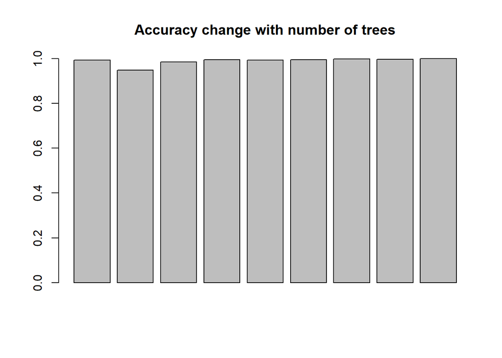

```r
barplot(accuracy_list,main="Accuracy change with number of trees")
```

```r
optimal_nr_trees <- which.is.max(accuracy_list)

paste("Optimal nr_of_trees: ", optimal_nr_trees, " accuracy: ", accuracy_list[optimal_nr_trees])
```

```
## [1] "Optimal nr_of_trees:  9  accuracy:  1"
```

```r
#rf_model$predicted
rf_pred <- predict(rf_model, test_data)
rf_confucius_matrix <- confusionMatrix(factor(rf_pred),test_data[,1])
#rf_confucius_matrix

rf_avg_error <- mean(rf_pred != test_data[,1])
rf_avg_error # Just another evaluation measure
```

```
## [1] 0
```

```r
rf_confucius_matrix
```

```
## Confusion Matrix and Statistics
##
##           Reference
## Prediction    e    p
##          e  507    0
##          p    0 1117
##
##                Accuracy : 1
##                  95% CI : (0.9977, 1)
##     No Information Rate : 0.6878
##     P-Value [Acc > NIR] : < 2.2e-16
##
##                   Kappa : 1
##  Mcnemar's Test P-Value : NA
##
##             Sensitivity : 1.0000
##             Specificity : 1.0000
##          Pos Pred Value : 1.0000
##          Neg Pred Value : 1.0000
##              Prevalence : 0.3122
##          Detection Rate : 0.3122
##    Detection Prevalence : 0.3122
##       Balanced Accuracy : 1.0000
##
##        'Positive' Class : e
##
```

```r
eval_summary(rf_confucius_matrix)
```

```
## [1] "precision:  1"
## [1] "recall: 1"
## [1] "f1_measure:  1"
## [1] "accuracy:  1"
```

With a split at 80% training data and 20% test, the model performs impeccable i.e perfectly. The random forest only takes the number of trees as argument. The number of trees was incremented until a satisfying result was achieved, as can be seen in the barplot.

To see which attributes are important for the decision trees we can make a variable importance plot.

## Variable importance plot

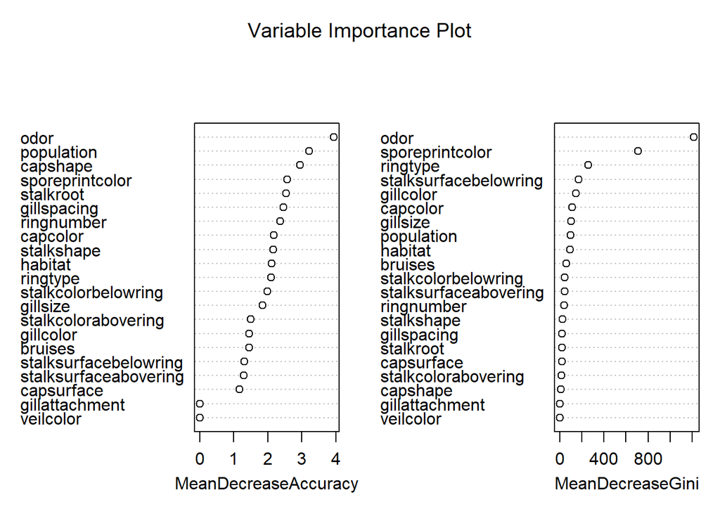

```r
varImpPlot(rf_model,main ="Variable Importance Plot")
```

In the variable importance plot, we can interpret the MeanDecreaseGini for a variable, as the variables ability to decrease the impurity. The mean is then how well this variable decrease the impurity on average over the splits where it’s used. It is clear that *odor* is by far the most important variable, and then other attributes are less important, and by far according to MeanDecreaseGini. The importance of the variables, can be used to decrease the dimensionality, by only using the most important variables, this will decrease the variance of the model, and increase the bias.

## Plotting the randomForest

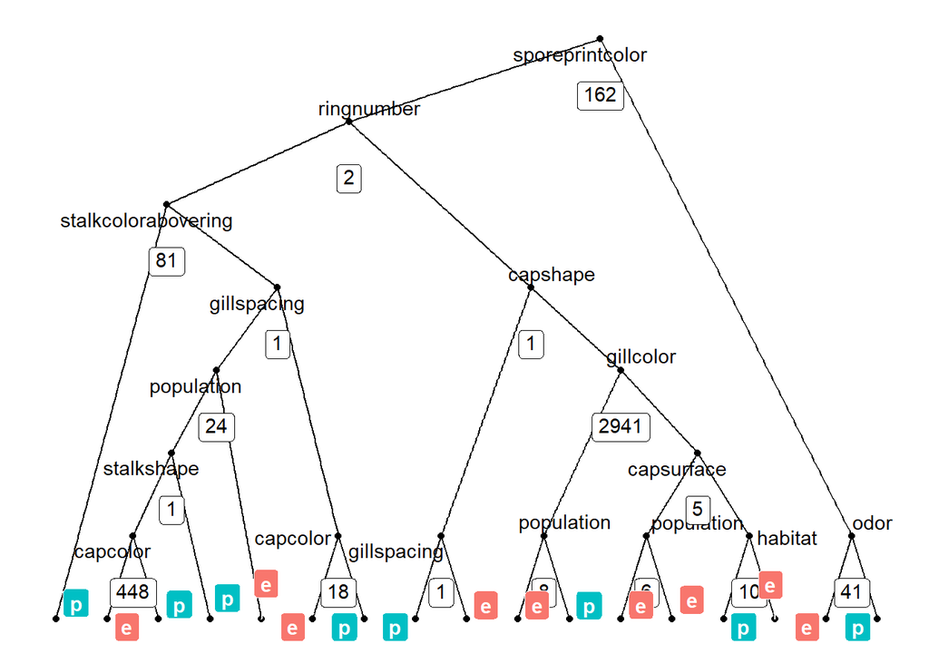

```r
tree_func(rf_model, tree_num)
```

The tree here gives a helpful interpretation to how a tree in the randomForrest behaves. With the small number of trees used to achieve perfect classification it is possible to see exactly how the randomForrest makes decisions.

## Confusion Matrices for model comparison

The confusion matrices are put here, for comparison.

[figure not shown]

[figure not shown]

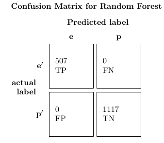

## Results

In this section the results are summarized.

[figure not shown]

```r
test_data_t <- as.numeric(test_data[,1] == "e")

nb_pred_t <- as.numeric(nb_pred == "e")
nb_pred_obj <- prediction(nb_pred_t,test_data_t)
nb_performance <- performance(nb_pred_obj,measure="tpr",x.measure="fpr")
plot(nb_performance,main = "ROC Curve for RandomForest on Mushroom data",col = "blue",lwd=3)
abline(a = 0, b = 1, lwd = 2, lty = 2) #Inserting a diagonal line in the ROC plot
```

```r
nb_roc_auc <- performance(nb_pred_obj,measure = "auc")
nb_roc_auc@y.values # Gives the auc value
```

```
## [[1]]
## [1] 0.8456435
```

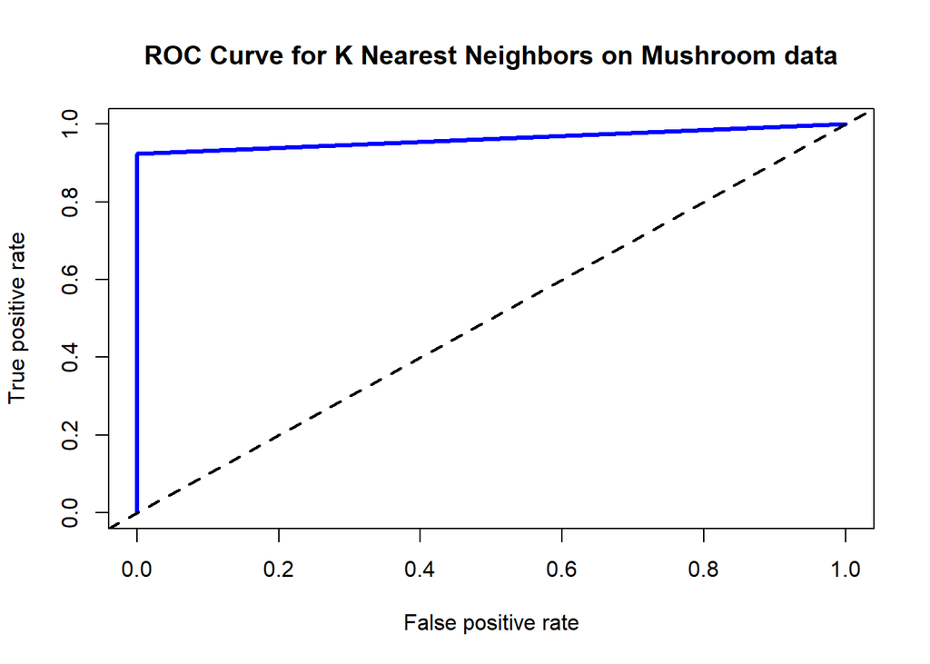

```r
knn_pred_t <- as.numeric(knn_pred == "e")
knn_pred_obj <- prediction(knn_pred_t, test_data_t)
knn_performance <- performance(knn_pred_obj,measure = "tpr", x.measure = "fpr")

plot(knn_performance,main = "ROC Curve for K Nearest Neighbors on Mushroom data",col = "blue",lwd=3)
abline(a = 0, b = 1, lwd = 2, lty = 2)
```

```r
knn_roc_auc <- performance(knn_pred_obj,measure = "auc")
knn_roc_auc@y.values # Gives the auc value
```

```
## [[1]]
## [1] 0.9625247
```

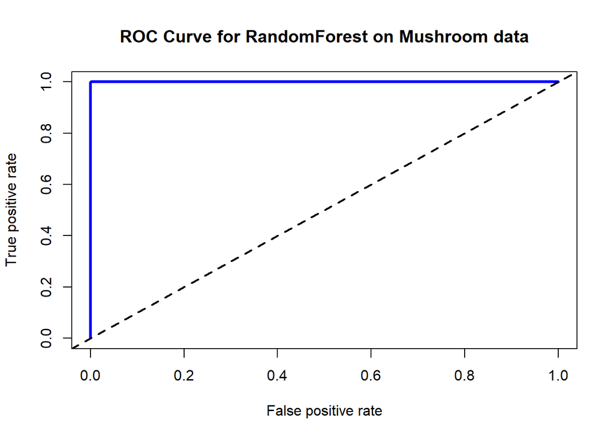

```r
rf_pred_t <- as.numeric(rf_pred == "e")  #Done to make our data numeric so roc can understand the p and e names.

#roc(test_data_t,pred_t,plot=TRUE) #I disliked this roc curve, because it was not visually precise enough.

rf_pred_obj <- prediction(rf_pred_t,test_data_t)

rf_performance <- performance(rf_pred_obj,measure="tpr",x.measure="fpr")
plot(rf_performance,main = "ROC Curve for RandomForest on Mushroom data",col = "blue",lwd=3) # This plot is added because it gives a little bit more clarity.
abline(a = 0, b = 1, lwd = 2, lty = 2)
```

```r
rf_roc_auc <- performance(rf_pred_obj,measure = "auc")
rf_roc_auc@y.values # Gives the auc value
```

```
## [[1]]
## [1] 1
```

In these ROC curves, it is clear that all of the classifiers are decent, and that knn and randomForest are best.

[figure not shown]

## Conclusion

In this mini-study, the clear winner is the *randomForest*. There are many other methods, that could perform equivalently well, but the study was kept mini, as requested. Other methods to include could be Boosting trees like *XGBoost* and neural networks. It is interesting that Naïve Bayes performs so poorly in comparison with knn and randomForest. Future work could be to use a better translation of nominal data into numerical data that knn can understand, and to use cross-validation. In this mushroom dataset, it was shown, that odor is a very important feature and that tuning the classifiers paramters to perform well can be done, by trying large intervals for solutions. The results are very useful, and I could consider trying this on real data, that I gather myself, but some of the attributes are difficult to assess, like the most important attribute odor.